# Exploratory Data Analysis on 12 STOCKS Across Different Sectors

## VISUALIZATION

The Scatter Plot with all the stock performance is show below:

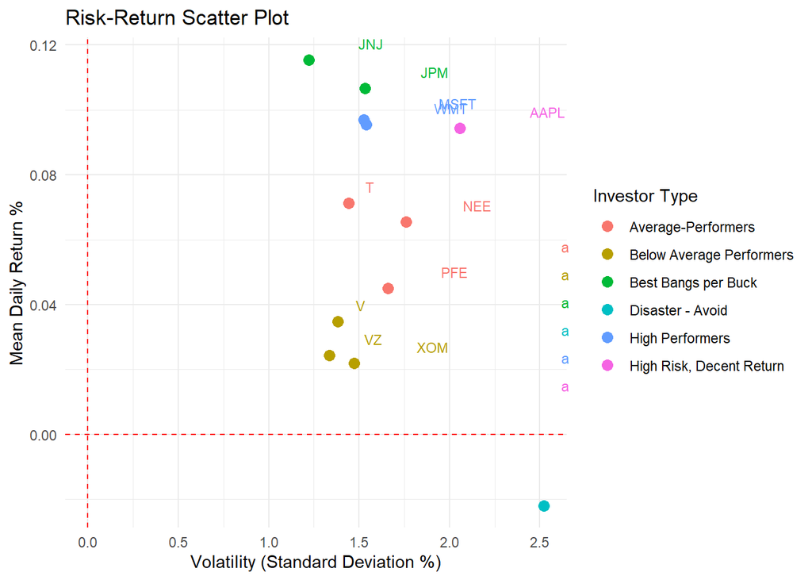

**INTERPRETATION**

The best performers not only have higher mean daily return, but also have good stability as indicated by the lower Standard deviation of the mean returns.

The Disaster stocks to avoid have high volatility and negative returns.

AAPL has High Volatility and High Returns, might be worth a gamble.

Below is the **20 day rolling average** compared to the **adjusted daily value** of each stock:

## Rolling Average Plots

### AAPL

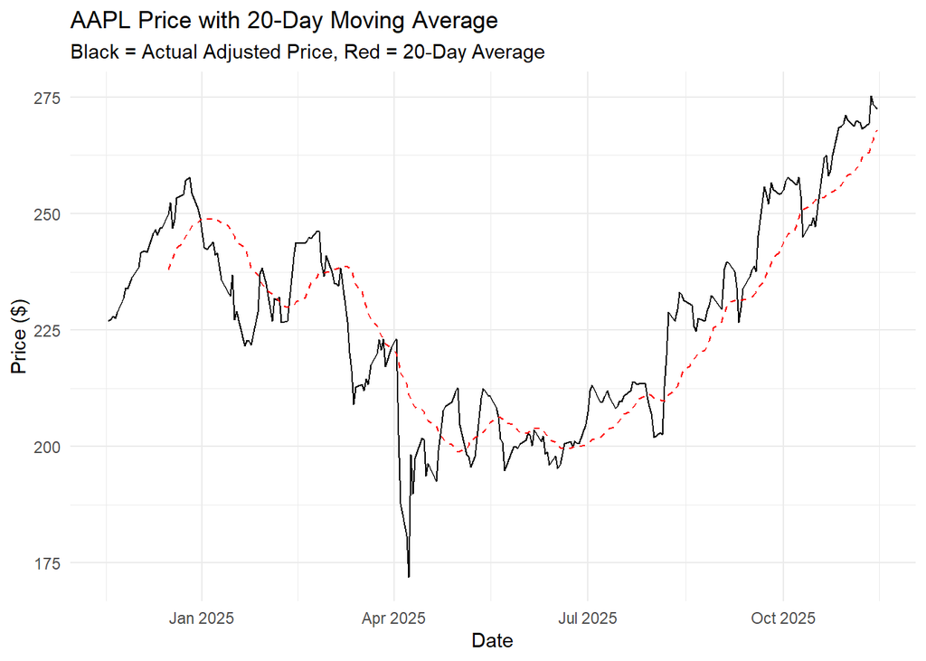

### MSFT

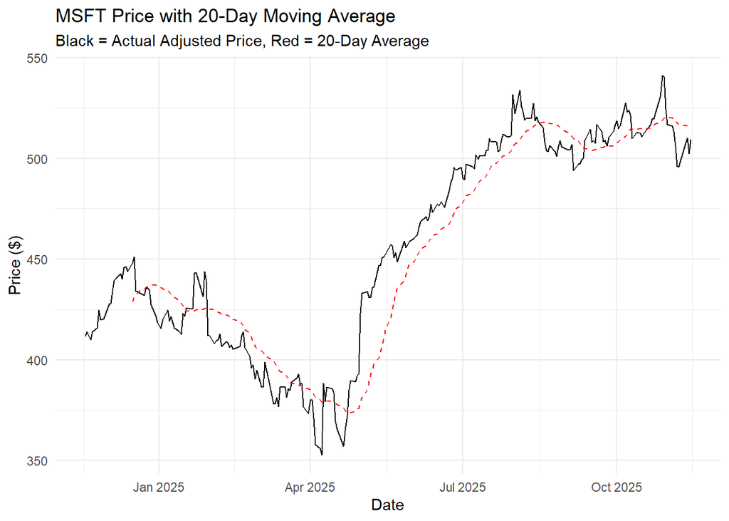

### JPM

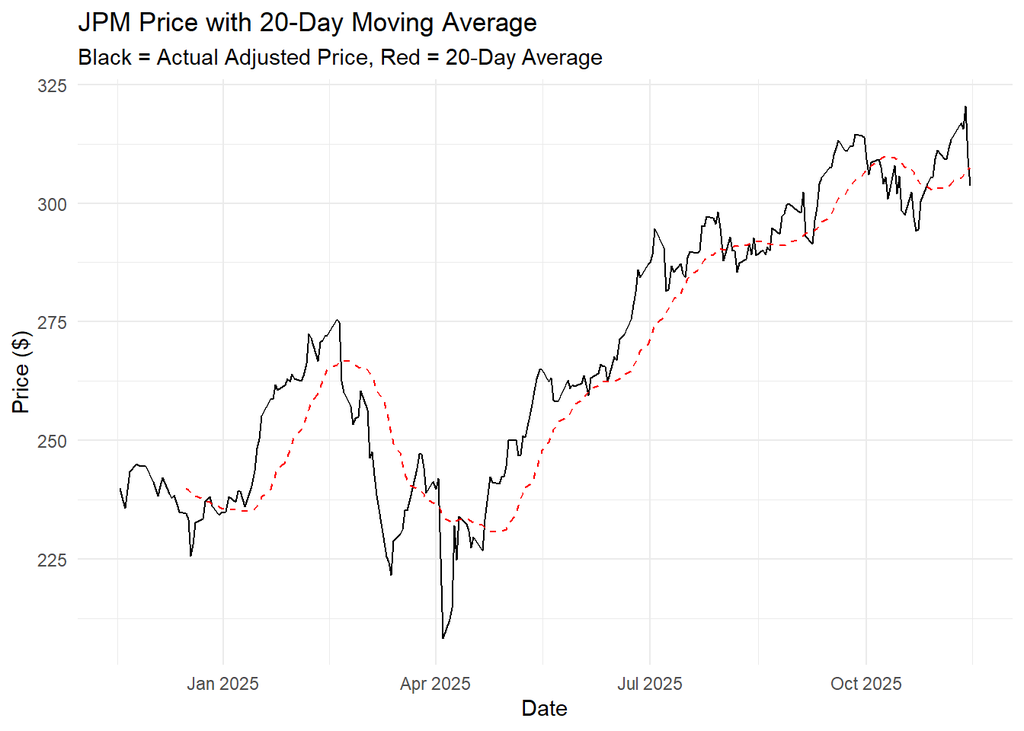

### V

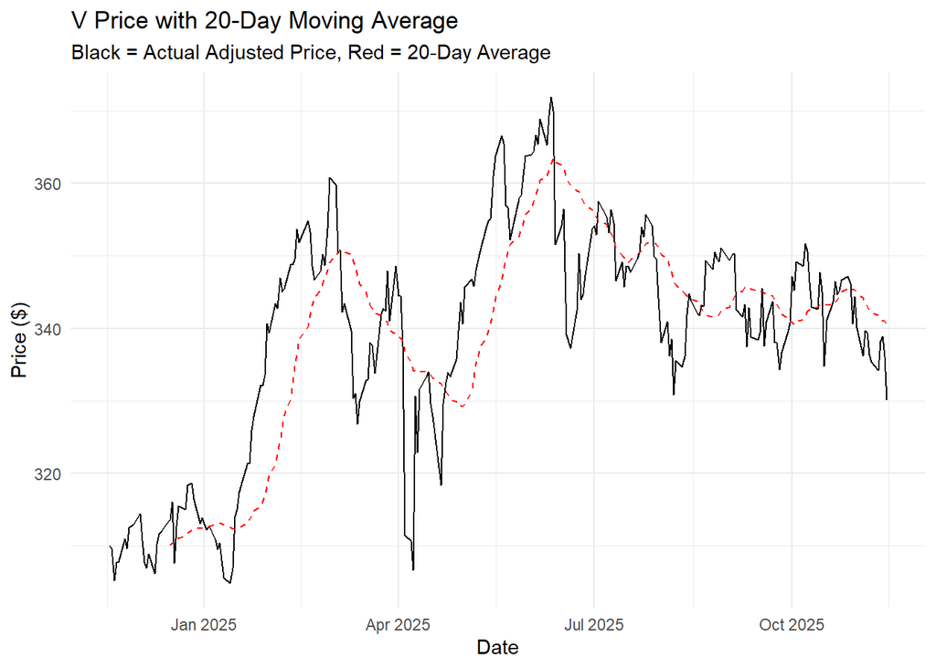

### JNJ

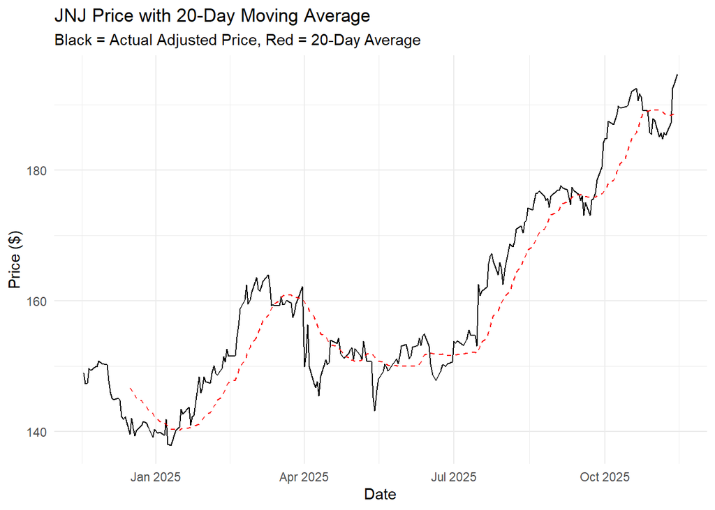

### PFE

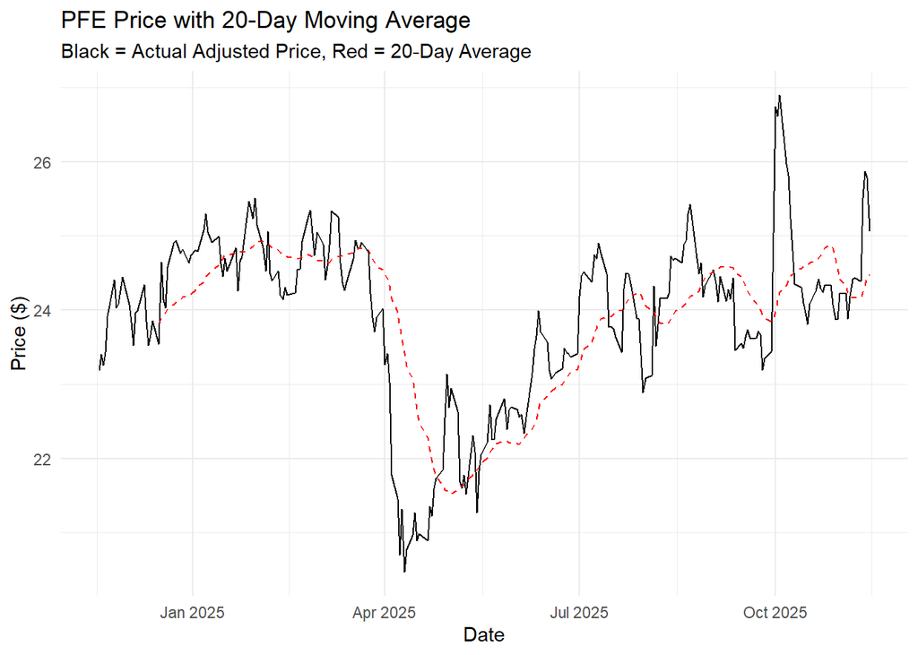

### WMT

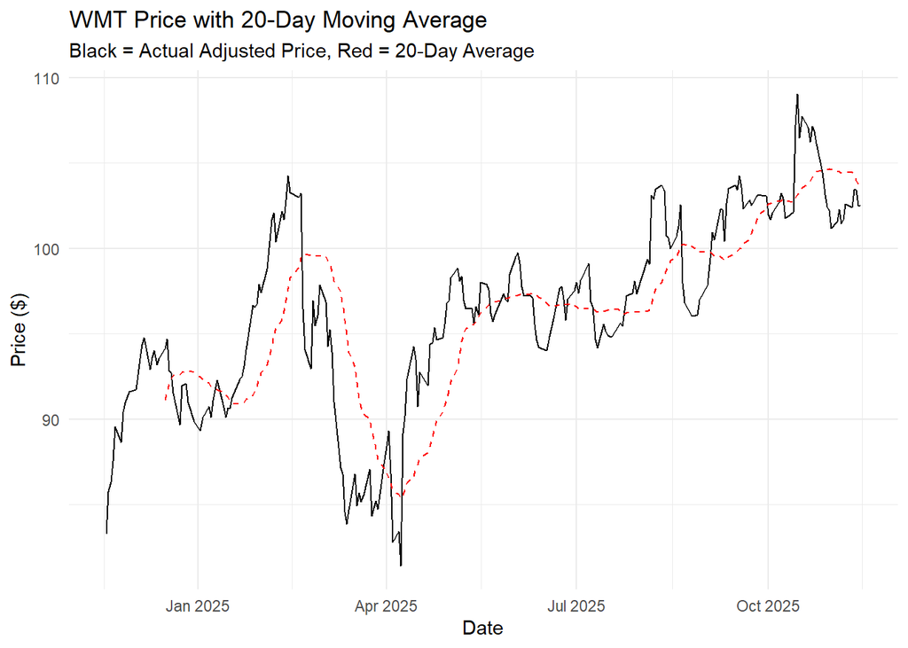

### NKE

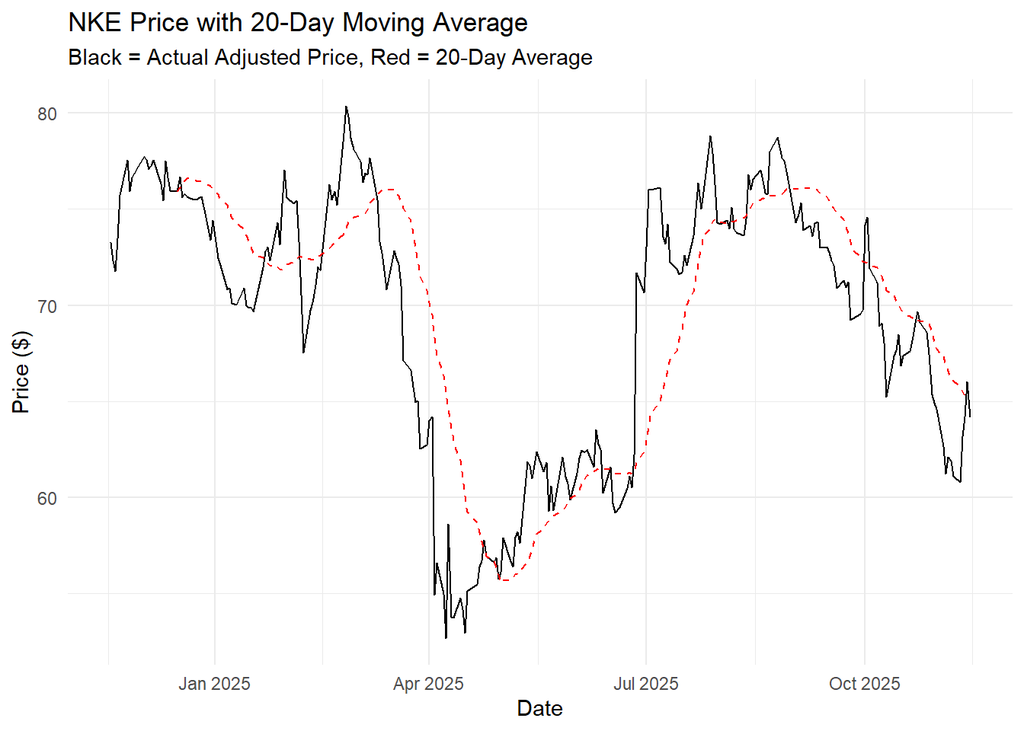

### XOM

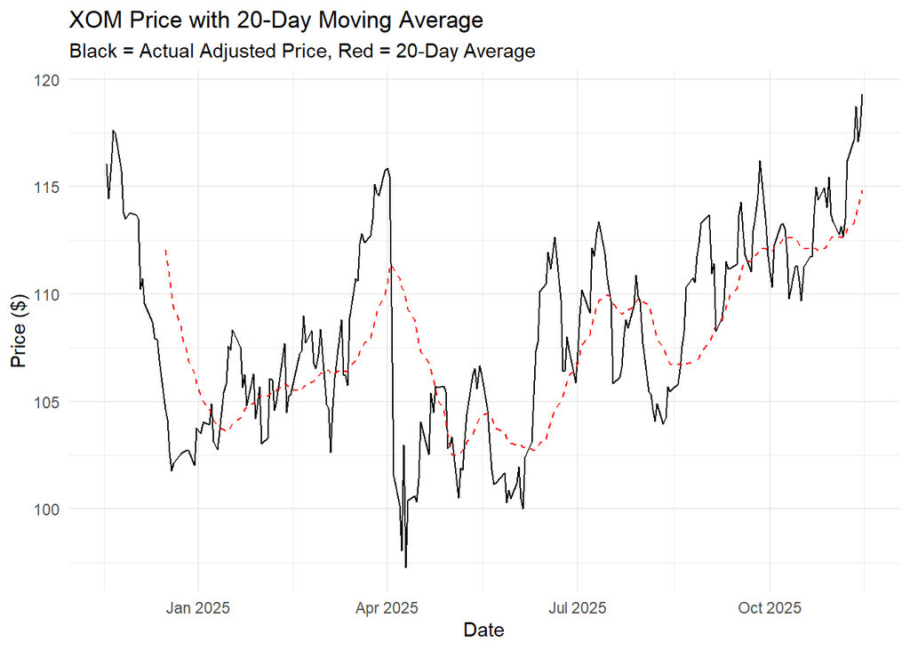

### VZ

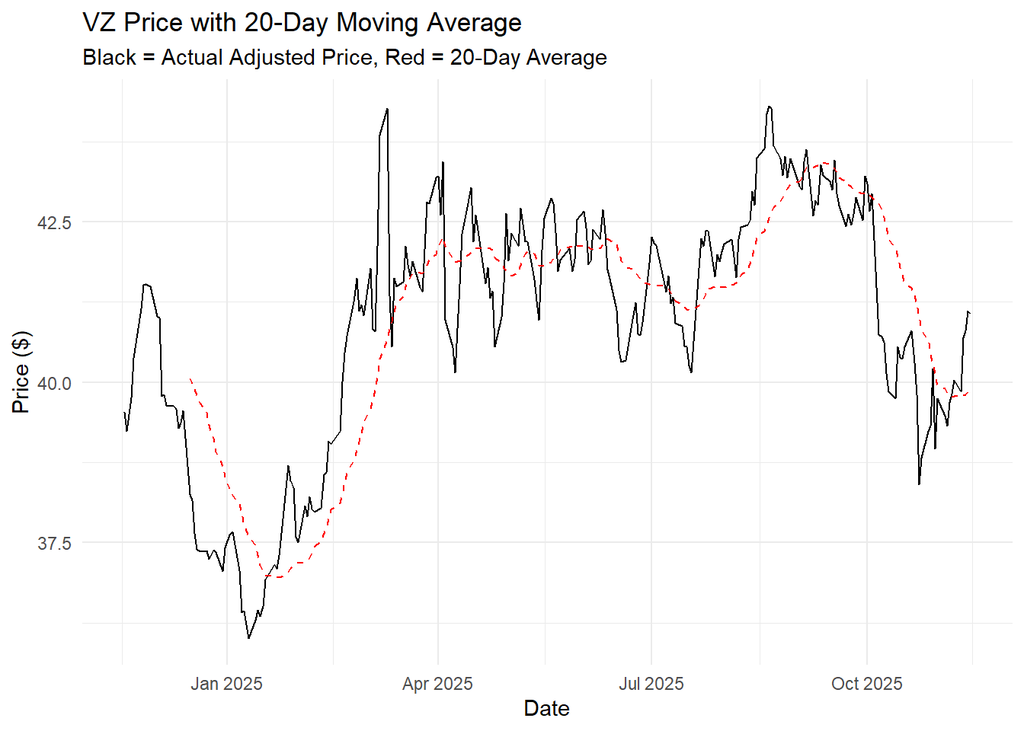

### T

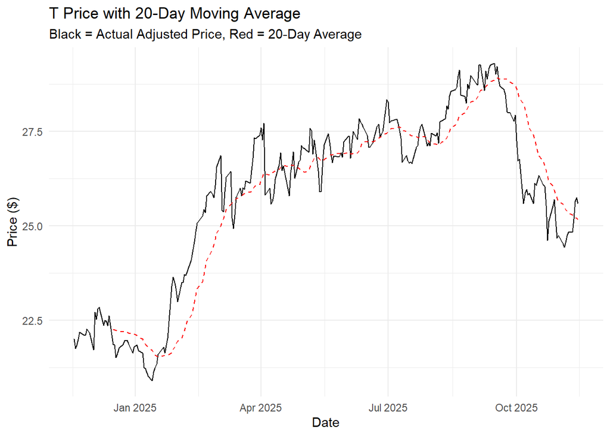

### NEE

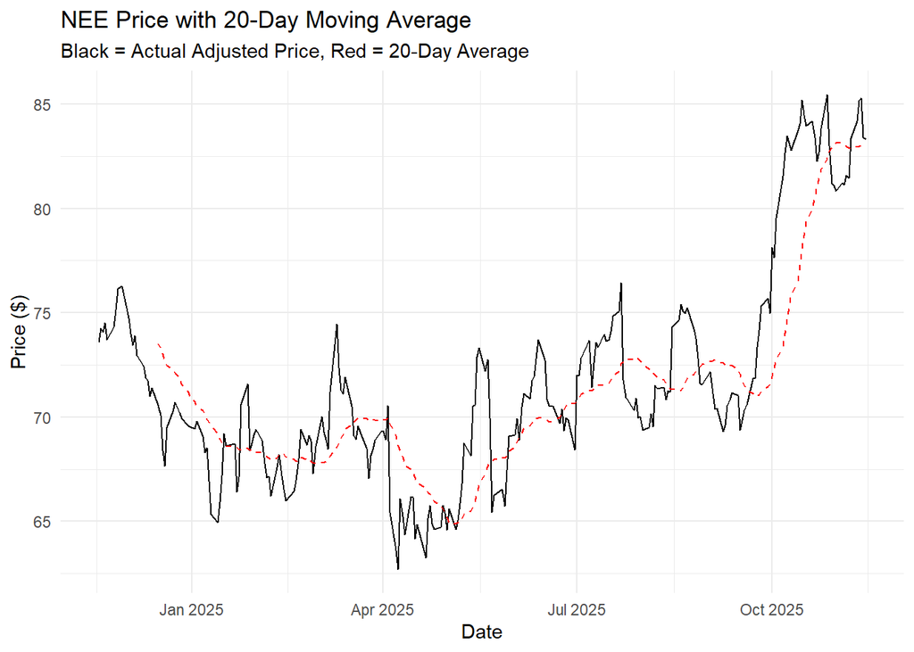

Below is the **Mean Return(% change)** of each stock over Time

## Mean Average Plots

### AAPL

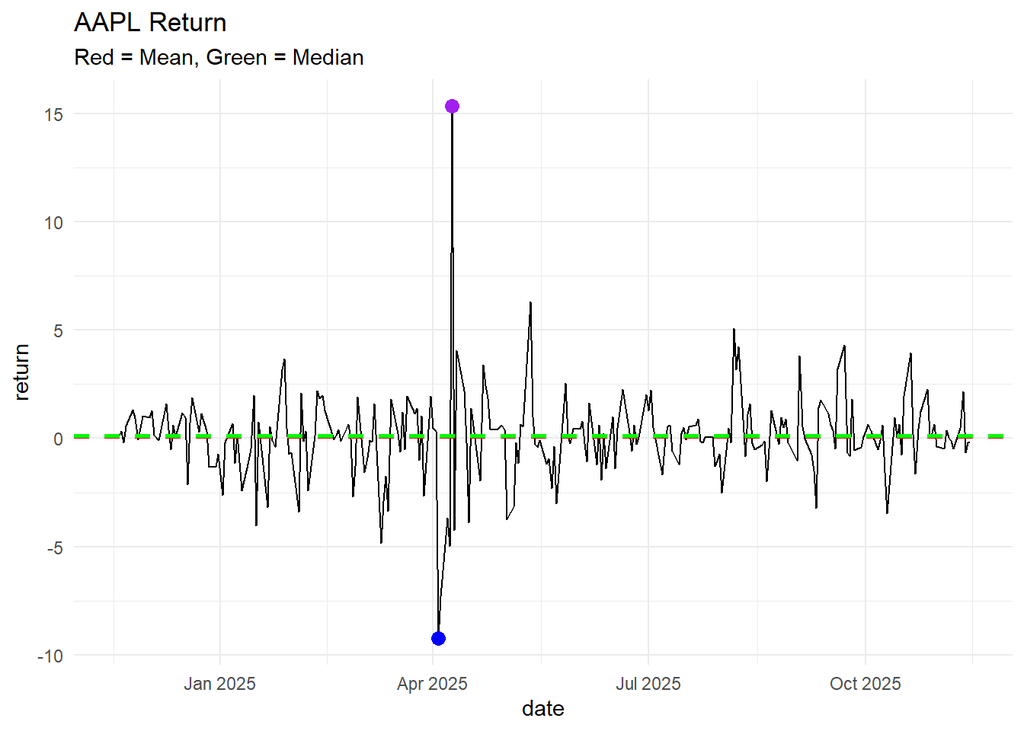

### MSFT

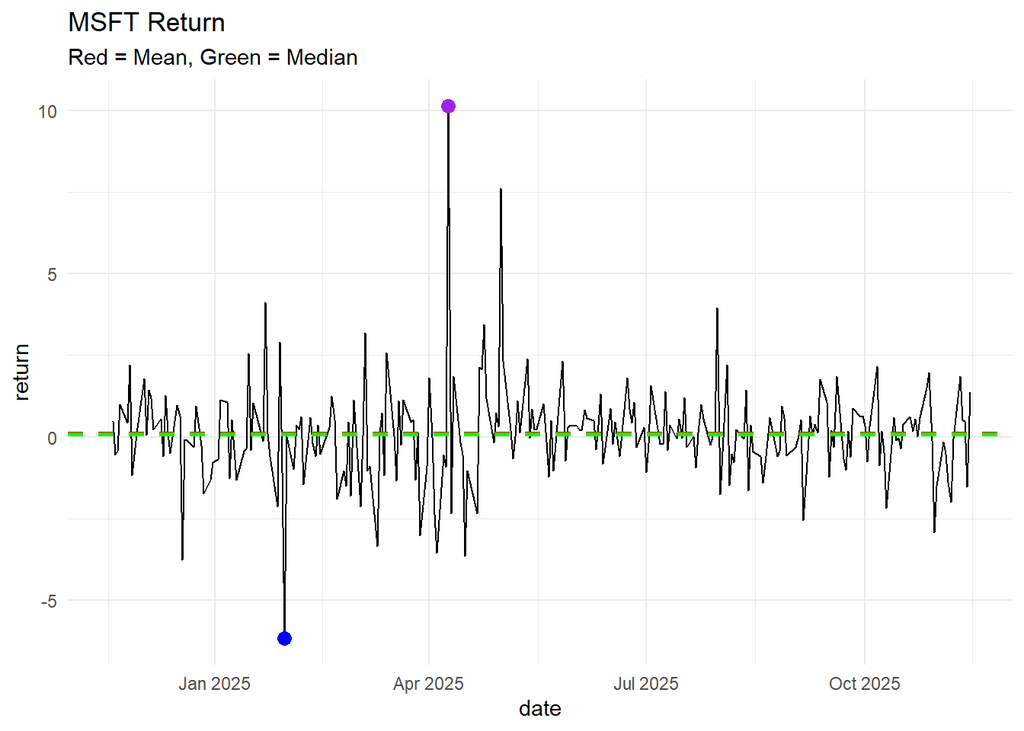

### JPM

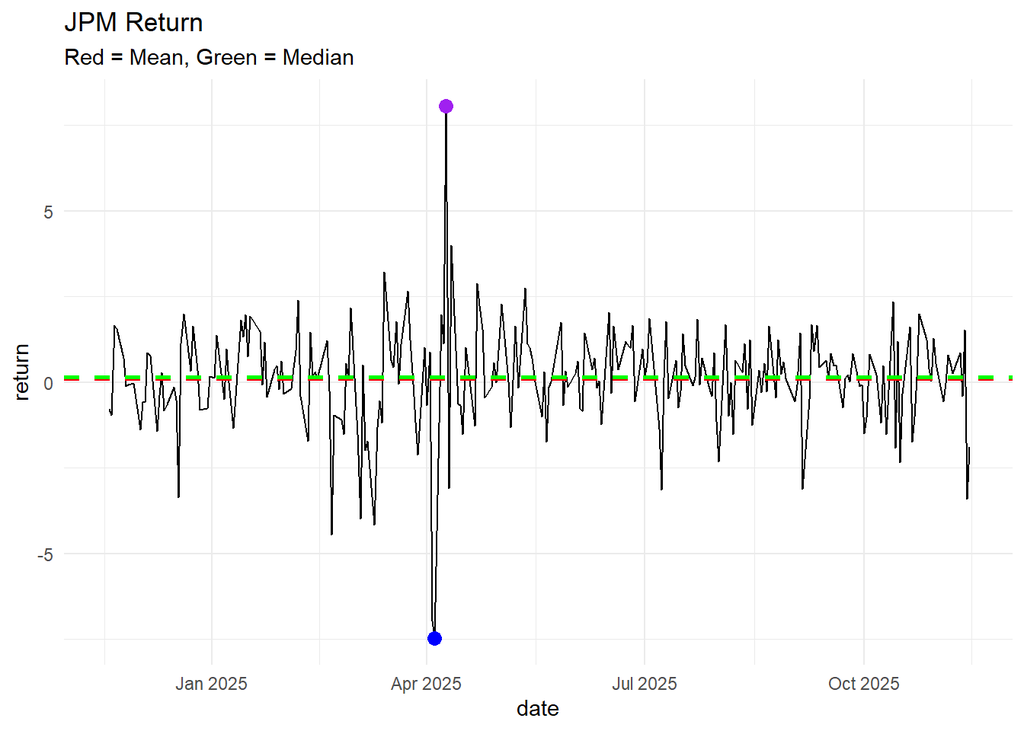

### V

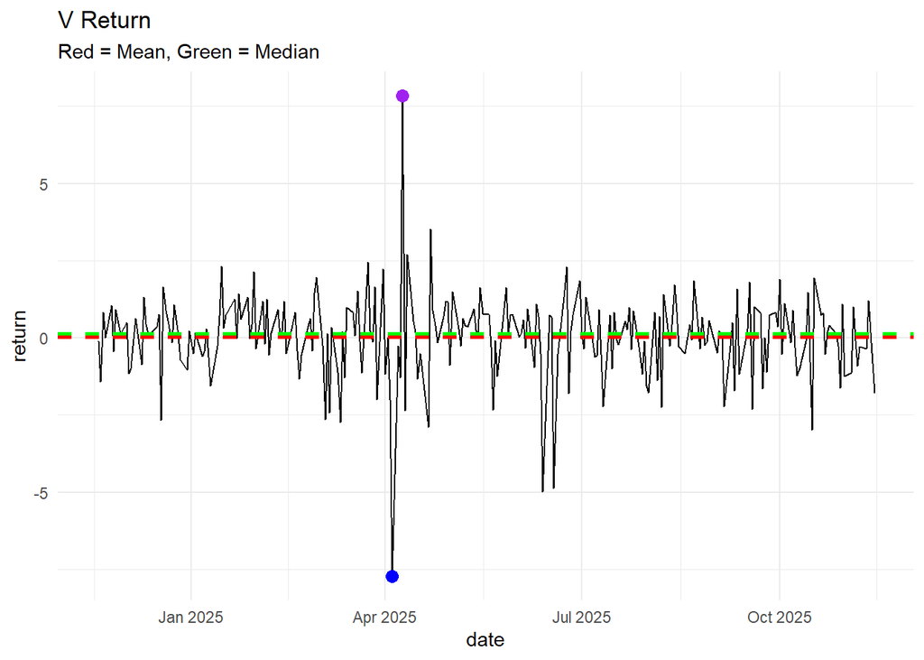

### JNJ

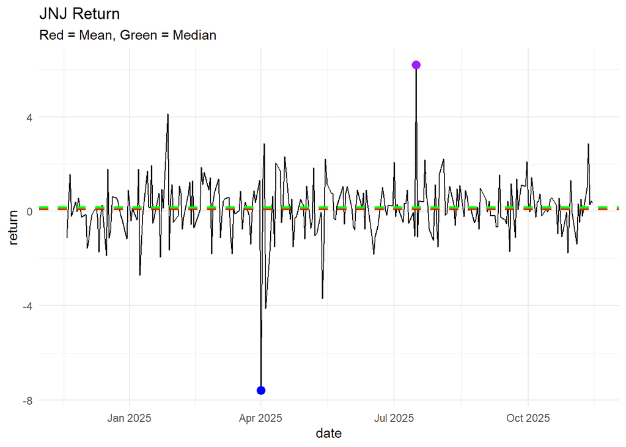

### PFE

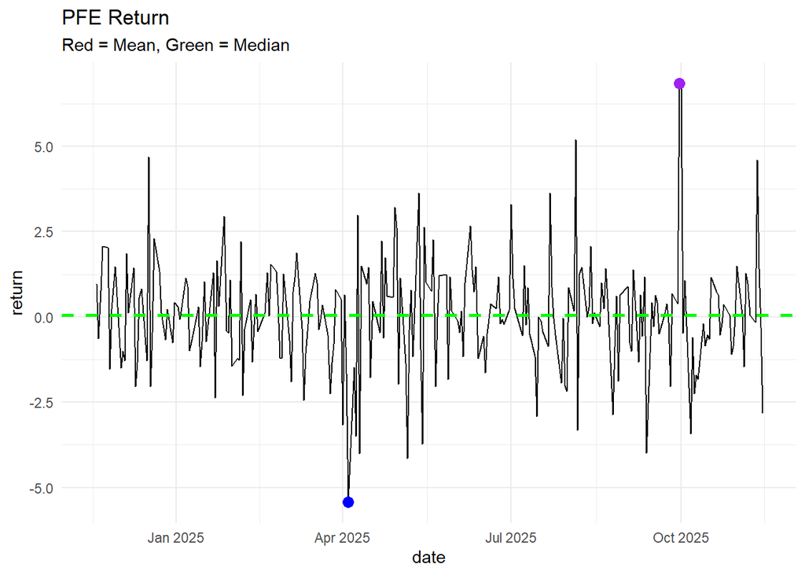

### WMT

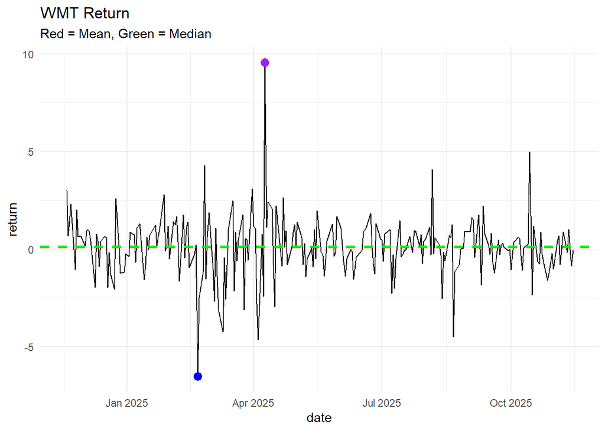

### NKE

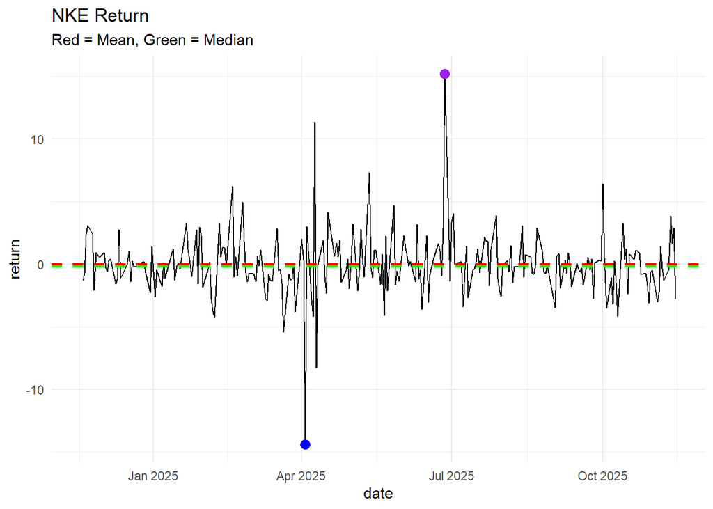

### XOM

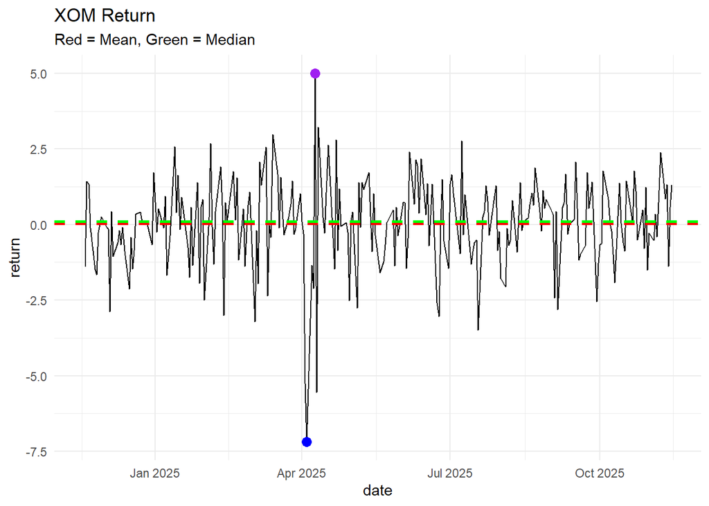

### VZ

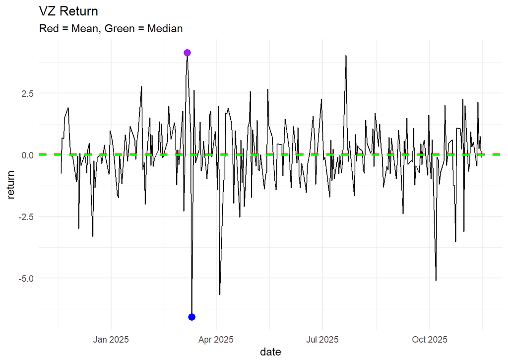

### T

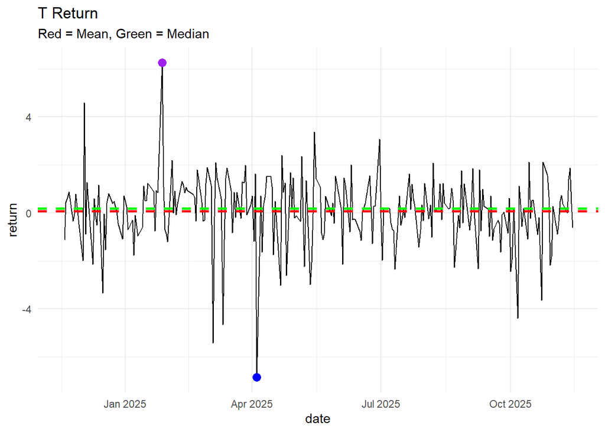